# Stock Trends Project

Nicholas Norcia

April 10, 2018

## Stock Dynamics

A stock market is where buyers and sellers trade shares of a company, and is one of the most popular ways for individuals and companies to invest money. The size of the world stock market is now estimated to be in the trillions. The largest stock market in the world is the New York Stock Exchange (NYSE), located in New York City. About 2,800 companies are listed on the NSYE. In this problem, we’ll look at the monthly stock prices of five of these companies: IBM, General Electric (GE), Procter and Gamble, Coca Cola, and Boeing.

The data used in this problem comes from Infochimps.

**Download and read** the following files into R, using the read.csv function:

`IBMStock.csv, GEStock.csv, ProcterGambleStock.csv, CocaColaStock.csv, and BoeingStock.csv`.

```r
#Reading in all of the csv files
#I added MSFT to show you I can do code on my own
setwd("N:/School/3710/Ch11/stock_dynamics_project")

IBM <- read.csv("IBMStock.csv")
GE <- read.csv("GEStock.csv")
ProcterGamble <- read.csv("ProcterGambleStock.csv")
CocaCola <- read.csv("CocaColaStock.csv")
Boeing <- read.csv("BoeingStock.csv")
MSFT <- read.csv("MSFT.csv")
```

Call the data frames “IBM”, “GE”, “ProcterGamble”, “CocaCola”, and “Boeing”, respectively.

Each data frame has two variables, described as follows:

```
Date: the date of the stock price, always given as the first of the month.
StockPrice: the average stock price of the company in the given month.
```

In this problem, we’ll take a look at how the stock dynamics of these companies have changed over time.

### Problem 1.1 - Summary Statistics

Before working with these data sets, we need to convert the dates into a format that R can understand. Take a look at the structure of one of the datasets using the str function. Right now, the date variable is stored as a factor. We can convert this to a “Date” object in R by using the following five commands (one for each data set):

```r
IBM$Date = as.Date(IBM$Date, "%m/%d/%y")
#
GE$Date = as.Date(GE$Date, "%m/%d/%y")
#
CocaCola$Date = as.Date(CocaCola$Date, "%m/%d/%y")
#
ProcterGamble$Date = as.Date(ProcterGamble$Date, "%m/%d/%y")
#
Boeing$Date = as.Date(Boeing$Date, "%m/%d/%y")
#
MSFT$Date = as.Date(MSFT$Date, "%m/%d/%y")
```

The first argument to the `as.Date` function is the variable we want to convert, and the second argument is the format of the Date variable. We can just overwrite the original Date variable values with the output of this function. Now, answer the following questions using the `str` and `summary` functions.

```r
#The summary and structure of data set IBM
summary(IBM)
```

```
##       Date              StockPrice
##  Min.   :1970-01-01   Min.   : 43.40
##  1st Qu.:1979-12-24   1st Qu.: 88.34
##  Median :1989-12-16   Median :112.11
##  Mean   :1989-12-15   Mean   :144.38
##  3rd Qu.:1999-12-08   3rd Qu.:165.41
##  Max.   :2009-12-01   Max.   :438.90
```

```r
str(IBM)
```

```
## 'data.frame':    480 obs. of  2 variables:
##  $ Date      : Date, format: "1970-01-01" "1970-02-01" ...
##  $ StockPrice: num  360 347 327 320 270 ...
```

```r
#The summary and structure of data set GE
summary(GE)
```

```
##       Date              StockPrice
##  Min.   :1970-01-01   Min.   :  9.294
##  1st Qu.:1979-12-24   1st Qu.: 44.214
##  Median :1989-12-16   Median : 55.812
##  Mean   :1989-12-15   Mean   : 59.303
##  3rd Qu.:1999-12-08   3rd Qu.: 72.226
##  Max.   :2009-12-01   Max.   :156.844
```

```r
str(GE)
```

```
## 'data.frame':    480 obs. of  2 variables:
##  $ Date      : Date, format: "1970-01-01" "1970-02-01" ...
##  $ StockPrice: num  74.3 70 72.2 74.3 66.7 ...
```

```r
#The summary and structure of data set CocaCola
summary(CocaCola)
```

```
##       Date              StockPrice
##  Min.   :1970-01-01   Min.   : 30.06
##  1st Qu.:1979-12-24   1st Qu.: 42.76
##  Median :1989-12-16   Median : 51.44
##  Mean   :1989-12-15   Mean   : 60.03
##  3rd Qu.:1999-12-08   3rd Qu.: 69.62
##  Max.   :2009-12-01   Max.   :146.58
```

```r
str(CocaCola)
```

```
## 'data.frame':    480 obs. of  2 variables:
##  $ Date      : Date, format: "1970-01-01" "1970-02-01" ...
##  $ StockPrice: num  83.4 81.6 81.3 76.8 69.3 ...
```

```r
#The summary and structure of data set ProcterGamble
summary(ProcterGamble)
```

```
##       Date              StockPrice
##  Min.   :1970-01-01   Min.   : 46.88
##  1st Qu.:1979-12-24   1st Qu.: 62.48
##  Median :1989-12-16   Median : 78.34
##  Mean   :1989-12-15   Mean   : 77.70
##  3rd Qu.:1999-12-08   3rd Qu.: 89.47
##  Max.   :2009-12-01   Max.   :149.62
```

```r
str(ProcterGamble)
```

```
## 'data.frame':    480 obs. of  2 variables:
##  $ Date      : Date, format: "1970-01-01" "1970-02-01" ...
##  $ StockPrice: num  111.9 111.5 108.5 106.3 73.3 ...
```

```r
sd(ProcterGamble$StockPrice)
```

```
## [1] 18.19414
```

```r
#The summary and structure of data set Boeing
summary(Boeing)
```

```
##       Date              StockPrice
##  Min.   :1970-01-01   Min.   : 12.74
##  1st Qu.:1979-12-24   1st Qu.: 34.64
##  Median :1989-12-16   Median : 44.88
##  Mean   :1989-12-15   Mean   : 46.59
##  3rd Qu.:1999-12-08   3rd Qu.: 57.21
##  Max.   :2009-12-01   Max.   :107.28
```

```r
str(Boeing)
```

```
## 'data.frame':    480 obs. of  2 variables:
##  $ Date      : Date, format: "1970-01-01" "1970-02-01" ...
##  $ StockPrice: num  27.9 22.4 23.1 21.6 18.9 ...
```

```r
#The summary and structure of data set MSFT
summary(MSFT)
```

```
##       Date           Open             High             Low
##  Min.   :NA     Min.   : 15.20   Min.   : 15.62   Min.   : 14.87
##  1st Qu.:NA     1st Qu.: 28.64   1st Qu.: 28.93   1st Qu.: 28.33
##  Median :NA     Median : 52.74   Median : 53.50   Median : 51.87
##  Mean   :NA     Mean   : 59.19   Mean   : 60.04   Mean   : 58.37
##  3rd Qu.:NA     3rd Qu.: 83.95   3rd Qu.: 85.00   3rd Qu.: 82.50
##  Max.   :NA     Max.   :178.94   Max.   :180.38   Max.   :175.75
##  NA's   :7720
##      Close            Volume            Adj.Close
##  Min.   : 15.15   Min.   :2.304e+06   Min.   : 0.06171
##  1st Qu.: 28.62   1st Qu.:4.145e+07   1st Qu.: 1.86385
##  Median : 52.75   Median :5.685e+07   Median :18.67078
##  Mean   : 59.24   Mean   :6.403e+07   Mean   :16.72645
##  3rd Qu.: 83.87   3rd Qu.:7.675e+07   3rd Qu.:23.90436
##  Max.   :179.94   Max.   :1.032e+09   Max.   :61.00000
##
```

```r
str(MSFT)
```

```
## 'data.frame':    7720 obs. of  7 variables:
##  $ Date     : Date, format: NA NA ...
##  $ Open     : num  59.9 60.3 57.5 57.5 57.5 ...
##  $ High     : num  61 60.5 57.5 57.8 58 ...
##  $ Low      : num  59.9 59.5 56.7 57.4 57.4 ...
##  $ Close    : num  61 59.7 57.2 57.5 57.7 ...
##  $ Volume   : int  52607700 80032200 49455600 22878400 19149500 23830000 27402500 25313700 22177500 26497400 ...
##  $ Adj.Close: num  61 59.7 57.2 57.5 57.7 ...
```

Our five datasets all have the same number of observations. How many observations are there in each data set?

Ans: 480 observations

### Problem 1.2 - Summary Statistics

What is the earliest year in our datasets?

Ans: 1970

### Problem 1.3 - Summary Statistics

What is the latest year in our datasets?

Ans: 2009

### Problem 1.4 - Summary Statistics

What is the mean stock price of IBM over this time period?

Ans: $144.38

### Problem 1.5 - Summary Statistics

What is the minimum stock price of General Electric (GE) over this time period?

Ans: $9.294

### Problem 1.6 - Summary Statistics

What is the maximum stock price of Coca-Cola over this time period?

Ans: $146.58

### Problem 1.7 - Summary Statistics

What is the median stock price of Boeing over this time period?

Ans: $44.88

### Problem 1.8 - Summary Statistics

What is the standard deviation of the stock price of Procter & Gamble over this time period?

Ans: $18.19414

### Problem 2.1 - Visualizing Stock Dynamics

Let’s plot the stock prices to see if we can visualize trends in stock prices during this time period. Using the plot function, plot the Date on the x-axis and the StockPrice on the y-axis, for Coca-Cola.

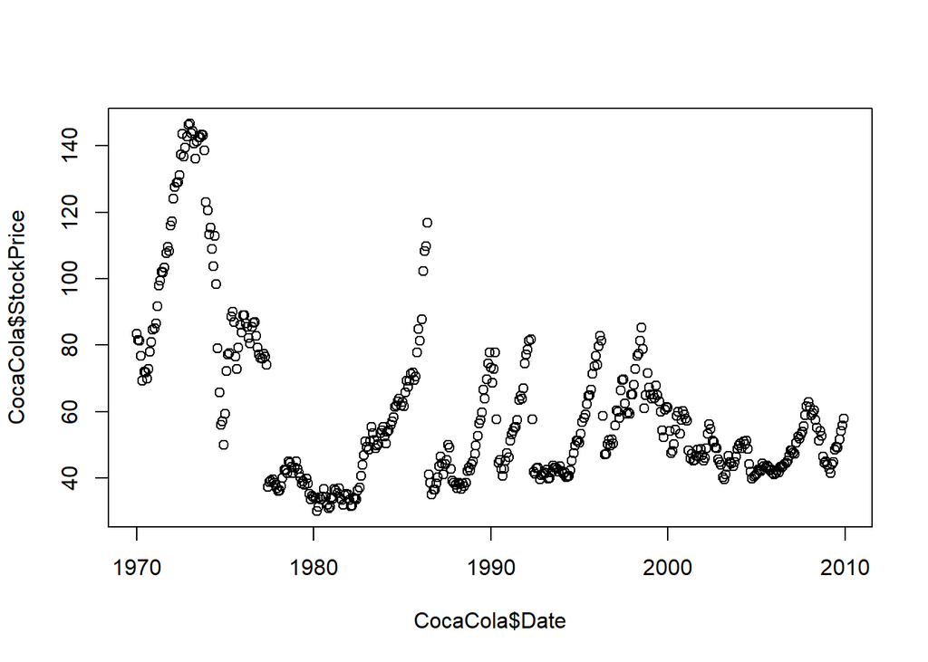

```r
plot(CocaCola$Date,CocaCola$StockPrice)
```

This plots our observations as points, but we would really like to see a line instead, since this is a continuous time period. To do this, add the argument type=“l” to your plot command, and re-generate the plot (the character is quotes is the letter l, for line). You should now see a line plot of the Coca-Cola stock price.

`plot(CocaCola$Date, CocaCola$StockPrice, type="l")`

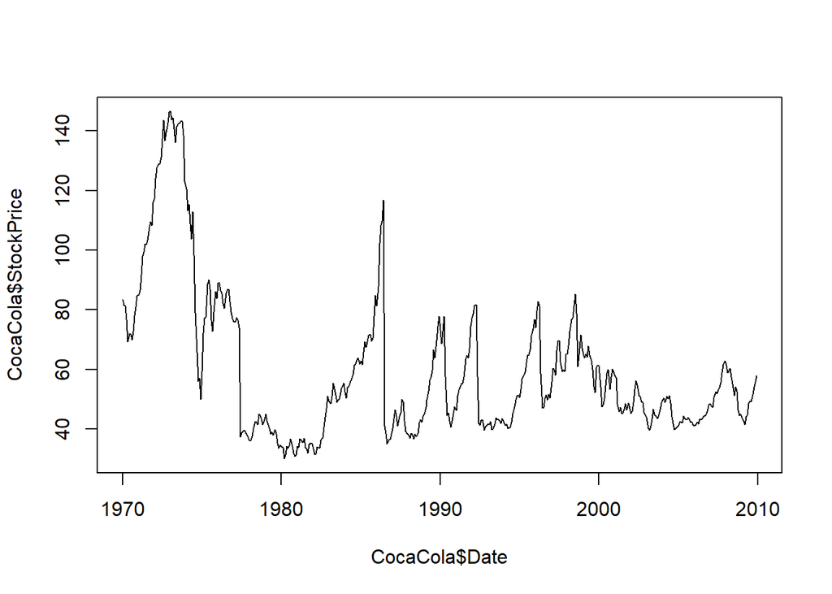

```r
plot(CocaCola$Date, CocaCola$StockPrice, type="l")
```

Around what year did Coca-Cola has its highest stock price in this time period?  
1973  
1980  
1985  
1995  
2008

Ans: 1973

Around what year did Coca-Cola has its lowest stock price in this time period?  
1973  
1980  
1985  
1995  
2008

Ans: 1980

### Problem 2.2 - Visualizing Stock Dynamics

Now, let’s add the line for Procter & Gamble too. You can add a line to a plot in R by using the lines function instead of the plot function. Keeping the plot for Coca-Cola open, type in your R console:

`lines(ProcterGamble$Date, ProcterGamble$StockPrice)`

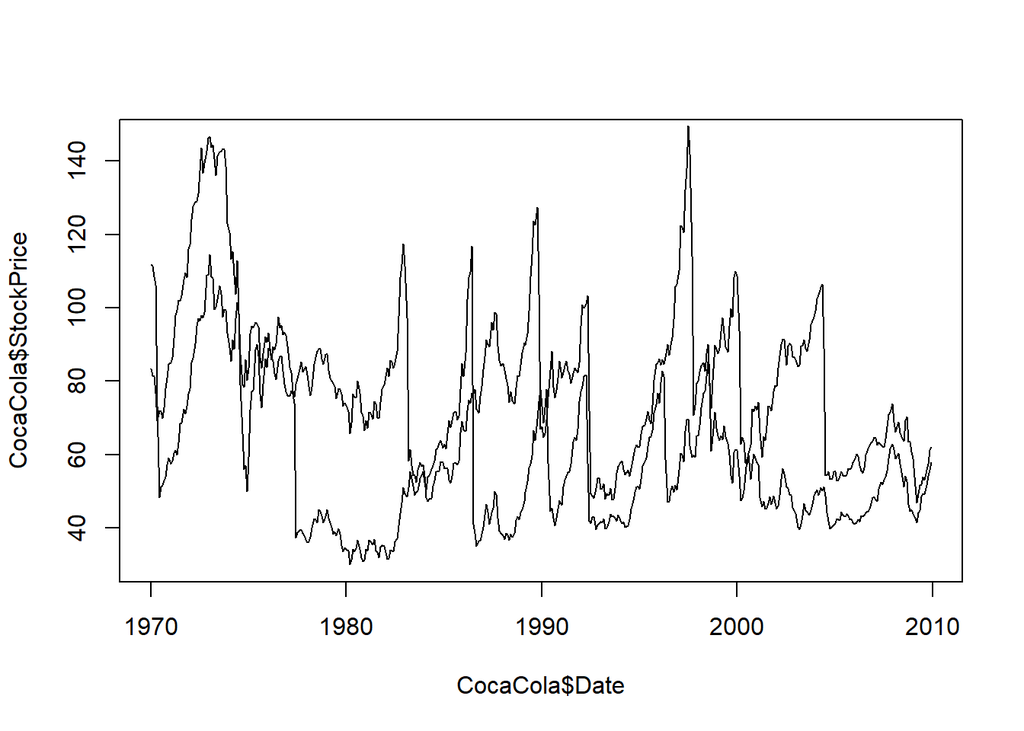

```r
plot(CocaCola$Date, CocaCola$StockPrice, type="l")
lines(ProcterGamble$Date, ProcterGamble$StockPrice)
```

Unfortunately, it’s hard to tell which line is which. Let’s fix this by giving each line a color. First, re-run the plot command for Coca-Cola, but add the argument `col="red"`. You should see the plot for Coca-Cola show up again, but this time in red. Now, let’s add the Procter & Gamble line (using the lines function like we did before), adding the argument `col="blue"`. You should now see in your plot the Coca-Cola stock price in red, and the Procter & Gamble stock price in blue.

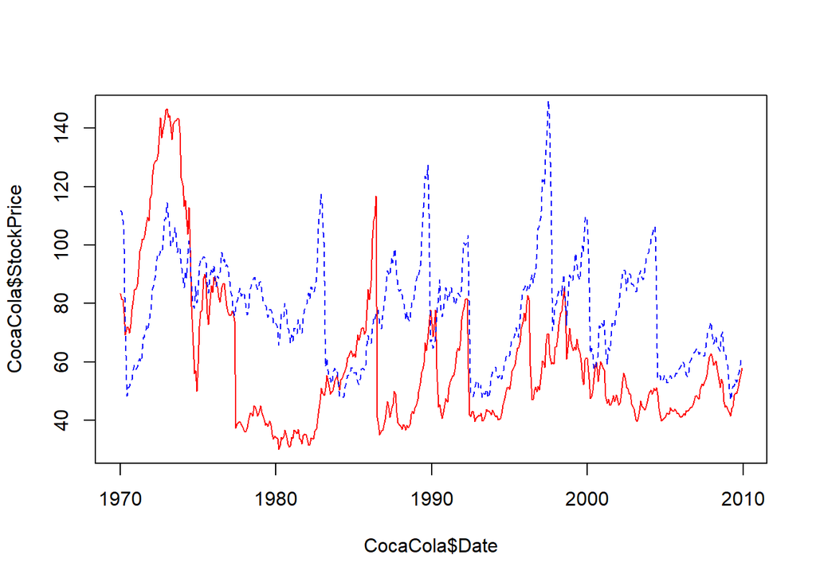

```r
plot(CocaCola$Date, CocaCola$StockPrice, type="l", col="red")
lines(ProcterGamble$Date, ProcterGamble$StockPrice, col="blue", lty=2)
```

As an alternative choice to changing the colors, you could instead change the line type of the Procter & Gamble line by adding the argument `lty=2`. This will make the Procter & Gamble line dashed.

Using this plot, answer the following questions.

In March of 2000, the technology bubble burst, and a stock market crash occurred. According to this plot, which company’s stock dropped more?

Coca-Cola  
Procter and Gamble

Ans: Proctor Gamble dropped more.

### Problem 2.3 - Visualizing Stock Dynamics

Answer these questions using the plot you generated in the previous problem.

Around 1983, the stock for one of these companies (Coca-Cola or Procter and Gamble) was going up, while the other was going down. Which one was going up?

Coca-Cola  
Procter and Gamble

Ans: CocaCola, I cannot really tell without altering the code.

In the time period shown in the plot, which stock generally has lower values?

Coca-Cola  
Procter and Gamble

Ans: CocaCola

### Problem 3.1 - Visualizing Stock Dynamics 1995-2005

Let’s take a look at how the stock prices changed from 1995-2005 for all five companies. Use following plot command:

`plot(CocaCola$Date[301:432], CocaCola$StockPrice[301:432], type="l", col="red", ylim=c(0,210))`

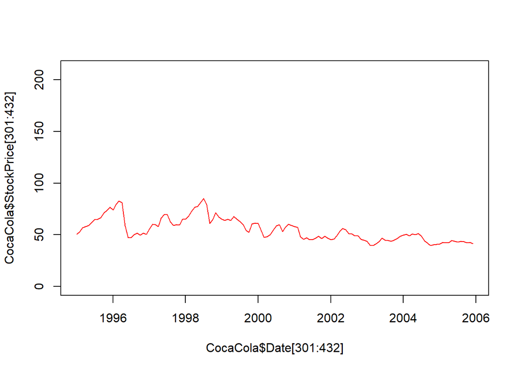

```r
plot(CocaCola$Date[301:432], CocaCola$StockPrice[301:432], type="l", col="red", ylim=c(0,210))
```

This will plot the CocaCola stock prices from 1995 through 2005, which are the observations numbered from 301 to 432. The additional argument, ylim=c(0,210), makes the y-axis range from 0 to 210. This will allow us to see all of the stock values when we add in the other companies.

Now, use the lines function to add in the other four companies, remembering to only plot the observations from 1995 to 2005, or [301:432]. You don’t need the `"type" or "ylim"` arguments for the lines function, but remember to make each company a different color so that you can tell them apart. Some color options are `"red", "blue", "green", "purple", "orange", and "black"` . To see all of the color options in R, type `colors()` in your R console.

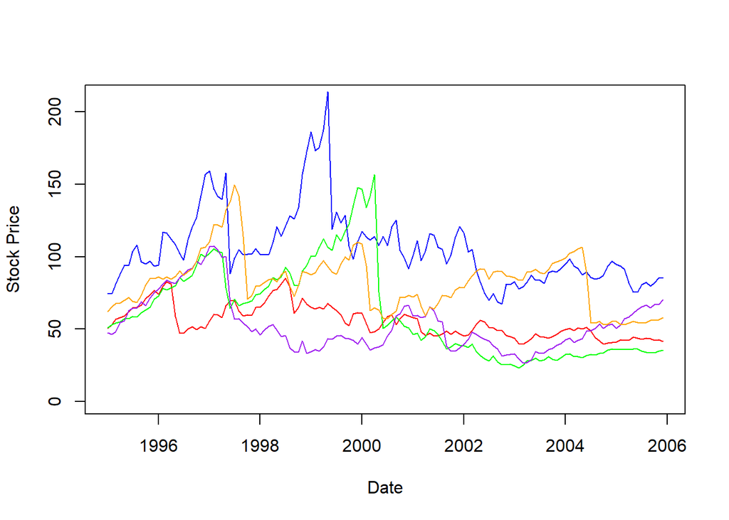

```r
plot(CocaCola$Date[301:432], CocaCola$StockPrice[301:432], type="l", col="red", ylim=c(0,210), xlab = "Date", ylab = "Stock Price")
lines(IBM$Date[301:432], IBM$StockPrice[301:432], col="blue")
lines(GE$Date[301:432], GE$StockPrice[301:432], col="green")
lines(Boeing$Date[301:432], Boeing$StockPrice[301:432], col="purple")
lines(ProcterGamble$Date[301:432], ProcterGamble$StockPrice[301:432], col="orange")
```

(If you prefer to change the type of the line instead of the color, here are some options for changing the line type: `lty=2` will make the line dashed, `lty=3` will make the line dotted, `lty=4` will make the line alternate between dashes and dots, and `lty=5` will make the line long-dashed.)

Use this plot to answer the following four questions.

`plot(CocaCola$Date[301:432], CocaCola$StockPrice[301:432], type="l", col="red", ylim=c(0,210))`

`lines(ProcterGamble$Date[301:432], ProcterGamble$StockPrice[301:432], col="blue")`

`lines(IBM$Date[301:432], IBM$StockPrice[301:432], col="green")`

`lines(GE$Date[301:432], GE$StockPrice[301:432], col="purple")`

`lines(Boeing$Date[301:432], Boeing$StockPrice[301:432], col="orange")`

`abline(v=as.Date(c("2000-03-01")), lwd=2)`

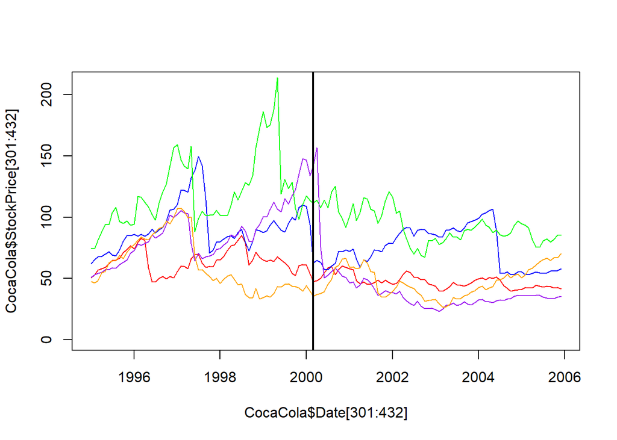

```r
plot(CocaCola$Date[301:432], CocaCola$StockPrice[301:432], type="l", col="red", ylim=c(0,210))

lines(ProcterGamble$Date[301:432], ProcterGamble$StockPrice[301:432], col="blue")

lines(IBM$Date[301:432], IBM$StockPrice[301:432], col="green")

lines(GE$Date[301:432], GE$StockPrice[301:432], col="purple")

lines(Boeing$Date[301:432], Boeing$StockPrice[301:432], col="orange")

abline(v=as.Date(c("2000-03-01")), lwd=2)
```

Which stock fell the most right after the technology bubble burst in March 2000?

Coca-Cola  
Procter and Gamble  
IBM  
General Electric (GE)  
Boeing

Ans: GE

### Problem 3.2 - Visualizing Stock Dynamics 1995-2005

Which stock reaches the highest value in the time period 1995-2005?

Coca-Cola  
Procter and Gamble  
IBM  
General Electric (GE)  
Boeing

Ans: IBM

### Problem 3.3 - Visualizing Stock Dynamics 1995-2005

In October of 1997, there was a global stock market crash that was caused by an economic crisis in Asia. Comparing September 1997 to November 1997, which companies saw a decreasing trend in their stock price? (Select all that apply.)

Coca-Cola  
Procter and Gamble  
IBM  
General Electric (GE)  
Boeing

Ans: Boeing and ProcterGamble

### Problem 3.4 - Visualizing Stock Dynamics 1995-2005

In the last two years of this time period (2004 and 2005) which stock seems to be performing the best, in terms of increasing stock price?

Coca-Cola  
Procter and Gamble  
IBM  
General Electric (GE)  
Boeing

Ans: Boeing

### Problem 4.1 - Monthly Trends

Lastly, let’s see if stocks tend to be higher or lower during certain months. Use the `tapply` command to calculate the mean stock price of IBM, sorted by months. To sort by months, use

`months(IBM$Date)`

as the second argument of the `tapply` function.

`tapply(IBM$StockPrice, months(IBM$Date), mean)`

```r
tapply(IBM$StockPrice, months(IBM$Date), mean)
```

```
##     April    August  December  February   January      July      June
##  152.1168  140.1455  140.7593  152.6940  150.2384  139.0670  139.0907
##     March       May  November   October September
##  152.4327  151.5022  138.0187  137.3466  139.0885
```

```r
mean(IBM$StockPrice)
```

```
## [1] 144.375
```

For IBM, compare the monthly averages to the overall average stock price. In which months has IBM historically had a higher stock price (on average)? Select all that apply.

January  
February  
March  
April  
May  
June  
July  
August  
September  
October  
November  
December

Ans: April, February, January, March, and May

### Problem 4.2 - Monthly Trends

Repeat the tapply function from the previous problem for each of the other four companies, and use the output to answer the remaining questions.

`tapply(GE$StockPrice, months(GE$Date), mean)`

`tapply(CocaCola$StockPrice, months(CocaCola$Date), mean)`

```r
#GE
tapply(GE$StockPrice, months(GE$Date), mean)
```

```
##     April    August  December  February   January      July      June
##  64.48009  56.50315  59.10217  62.52080  62.04511  56.73349  56.46844
##     March       May  November   October September
##  63.15055  60.87135  57.28879  56.23897  56.23913
```

```r
#CocaCola
tapply(CocaCola$StockPrice, months(CocaCola$Date), mean)
```

```
##     April    August  December  February   January      July      June
##  62.68888  58.88014  59.73223  60.73475  60.36849  58.98346  60.81208
##     March       May  November   October September
##  62.07135  61.44358  59.10268  57.93887  57.60024
```

```r
#ProcterGamble
tapply(ProcterGamble$StockPrice, months(ProcterGamble$Date), mean)
```

```
##     April    August  December  February   January      July      June
##  77.68671  76.82266  78.29661  79.02575  79.61798  76.64556  77.39275
##     March       May  November   October September
##  77.34761  77.85958  78.45610  76.67903  76.62385
```

```r
#Boeing
tapply(Boeing$StockPrice, months(Boeing$Date), mean)
```

```
##     April    August  December  February   January      July      June
##  47.04686  46.86311  46.17315  46.89223  46.51097  46.55360  47.38525
##     March       May  November   October September
##  46.88208  48.13716  45.14990  45.21603  46.30485
```

General Electric and Coca-Cola both have their highest average stock price in the same month. Which month is this?

January  
February  
March  
April  
May  
June  
July  
August  
September  
October  
November  
December

Ans: April

### Problem 4.3 - Monthly Trends

For the months of December and January, every company’s average stock is higher in one month and lower in the other. In which month are the stock prices lower?

December  
January

Ans: December